# Exploring the BRFSS data

## Setup

### Load packages

```r
library(ggplot2)
library(dplyr)
```

### Load data

```r
load("brfss2013.RData")
library(ggplot2)
```

## Part 1: Data

Since the data collected for BRFSS is basically an observational study and not an experiment, we can not infer a causal relationship between any of the variables in it, even if we find correlations. As for the sampling, it seems that stratified sampling has been used here, since all states have been made part of the study.  
The sampling within the states seems fairly random and inclusive for a survey with such objectives.  
Since this is not an experiment, assessing whether random assignment was used is irrelevant here.

## Part 2: Research questions

**Research quesion 1:** One question that we can explore using the data we have is if there is any correlation between a person’s mental health, and their financial status, or their financial worries. For that we can try to find patterns between and the person’s income category and the number days they felt that their mental health was not good, or if they have ever been told that they have a depressive disorder. We can also try to find patterns between the latter two variables their being worried/stressed about having enough money for nutrition or rent.

**Research quesion 2:** Another question that we can explore using the data we have is if there is an association between a person’s mental health, and the level of physical activity they engage in. However, we might not be able to conclude which affects which, or if there is any causal relationship between them at all. We can look for patterns of association between their physical activity categories and physical activity index, and the number of days they felt their mental health was not good, or if they have been told they have a depressive disorder. We can also explore any relation between their activity index and how often they felt worthless or depressed, which might be indicative of an emotional health issue.

**Research quesion 3:** One other question that we can explore from the given data is if people’s sleeping patterns, and their mental health is connected. More concretely, if we can find any pattern between inadequate, or less than average sleep (for which we will make a boolean variable indicating if the respondent sleeps less than 7 hours, which is the median, as well as the mean sleep time between the respondents), and if they have ever been told they have a depressive disorder, or the number of days they have suffered from poor mental health, or how often they felt depressed or worthless.

## Part 3: Exploratory data analysis

**Research quesion 1: Exploring assossiation between a person’s financial status and/or worries, and their mental health**

We can start with looking for association between the person’s income category, and days they felt their mental health was not good.

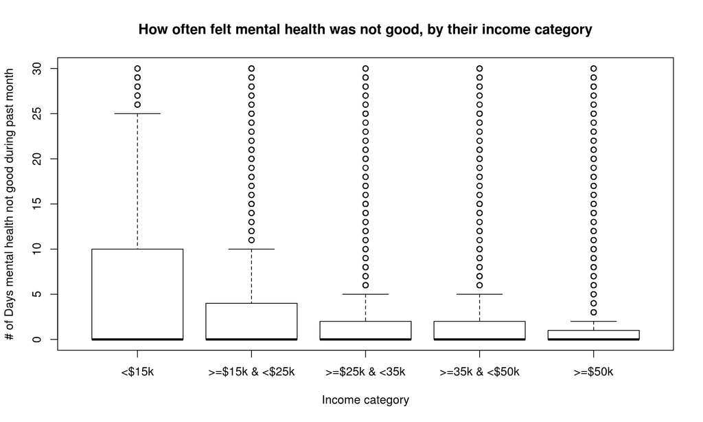

```r
attach(brfss2013)
boxplot(menthlth~X_incomg, main="How often felt mental health was not good, by their income category", xlab="Income category", ylab='# of Days mental health not good during past month', names=c('<$15k', '>=$15k & <$25k', '>=$25k & <35k', '>=35k & <$50k', '>=$50k'))
```

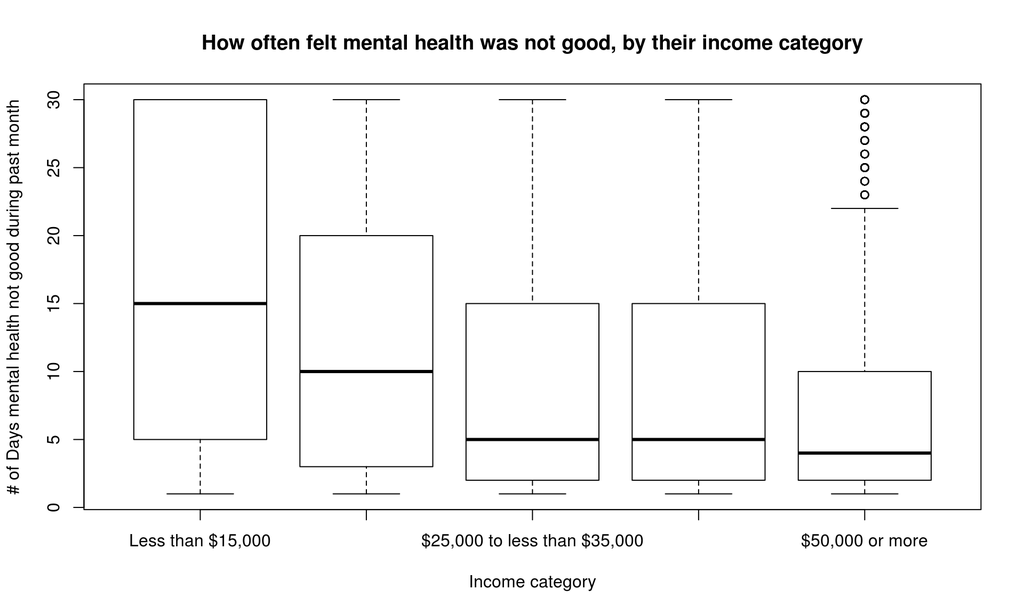

```r
mentsick <- subset(brfss2013, menthlth>0)
with(mentsick, boxplot(menthlth~X_incomg, main="How often felt mental health was not good, by their income category", xlab="Income category", ylab='# of Days mental health not good during past month'))
```

Exploring association between their income category, and if they have ever been told that they suffer from a depressive disorder.

```r
table(X_incomg, addepev2)
```

```
##                               addepev2
## X_incomg                          Yes     No
##   Less than $15,000             17971  33876
##   $15,000 to less than $25,000  18869  57376
##   $25,000 to less than $35,000   9609  39061
##   $35,000 to less than $50,000  11056  50258
##   $50,000 or more               26342 154423
```

These numbers won’t clarify the picture until we take proportions. Taking proportions along the rows, i.e. the proportion of people who have been told they have a depressive disorder, within each income category

```r
prop.table(table(X_incomg, addepev2), 1)
```

```
##                               addepev2
## X_incomg                             Yes        No
##   Less than $15,000            0.3466160 0.6533840
##   $15,000 to less than $25,000 0.2474785 0.7525215
##   $25,000 to less than $35,000 0.1974317 0.8025683
##   $35,000 to less than $50,000 0.1803177 0.8196823
##   $50,000 or more              0.1457251 0.8542749
```

We can also see if there is any association between a person’s income category, and how often they felt depressed or worthless during the past 30 days. For this we take the proportion of how often people felt depressed (1st table) or worthless (2nd table) in the past month, in each income category.

```r
prop.table(table(X_incomg, misdeprd), 1)
```

```
##                               misdeprd
## X_incomg                               All        Most        Some
##   Less than $15,000            0.032580645 0.052903226 0.122903226
##   $15,000 to less than $25,000 0.012512614 0.021997982 0.071241171
##   $25,000 to less than $35,000 0.004137116 0.012411348 0.046690307
##   $35,000 to less than $50,000 0.003290917 0.010969724 0.032250987
##   $50,000 or more              0.001335470 0.003739316 0.019631410
##                               misdeprd
## X_incomg                          A little        None
##   Less than $15,000            0.130322581 0.661290323
##   $15,000 to less than $25,000 0.099293643 0.794954591
##   $25,000 to less than $35,000 0.083037825 0.853723404
##   $35,000 to less than $50,000 0.066476525 0.887011847
##   $50,000 or more              0.047876603 0.927417201
```

```r
prop.table(table(X_incomg, miswtles), 1)
```

```
##                               miswtles
## X_incomg                               All        Most        Some
##   Less than $15,000            0.048756861 0.053277365 0.108169196
##   $15,000 to less than $25,000 0.016979988 0.022033556 0.063270669
##   $25,000 to less than $35,000 0.009198813 0.009792285 0.041543027
##   $35,000 to less than $50,000 0.005711775 0.010105448 0.032073814
##   $50,000 or more              0.001737503 0.003140871 0.021384657
##                               miswtles
## X_incomg                          A little        None
##   Less than $15,000            0.105263158 0.684533419
##   $15,000 to less than $25,000 0.080654942 0.817060845
##   $25,000 to less than $35,000 0.068842730 0.870623145
##   $35,000 to less than $50,000 0.063268893 0.888840070
##   $50,000 or more              0.042568832 0.931168137
```

Now we can explore the possibility of association between how often they were worried about having money for food, and if they have ever been told that they suffer from a depressive disorder

```r
table(scntmeal, addepev2)
```

```
##            addepev2
## scntmeal      Yes    No
##   Always     1709  1626
##   Usually     967  1213
##   Sometimes  2619  5616
##   Rarely     1793  6066
##   Never      6376 37800
```

Taking proportions again, along the rows, i.e. the proportion of people who have been told they have a depressive disorder, across each category of people, classified by their responses to how often they felt worried about having money for food (1st table) or to pay rent (2nd table).

```r
prop.table(table(scntmeal, addepev2), 1)
```

```
##            addepev2
## scntmeal          Yes        No
##   Always    0.5124438 0.4875562
##   Usually   0.4435780 0.5564220
##   Sometimes 0.3180328 0.6819672
##   Rarely    0.2281461 0.7718539
##   Never     0.1443318 0.8556682
```

```r
prop.table(table(scntmony, addepev2), 1)
```

```
##            addepev2
## scntmony          Yes        No
##   Always    0.4710583 0.5289417
##   Usually   0.3951411 0.6048589
##   Sometimes 0.2463101 0.7536899
##   Rarely    0.1788060 0.8211940
##   Never     0.1399576 0.8600424
```

To wrap up, we can further explore the associations between how many days a person felt that their mental health was not good in the past month, and how often they felt worried or stressed about having enough money to buy nutritious meals or paying the rent during the past year.

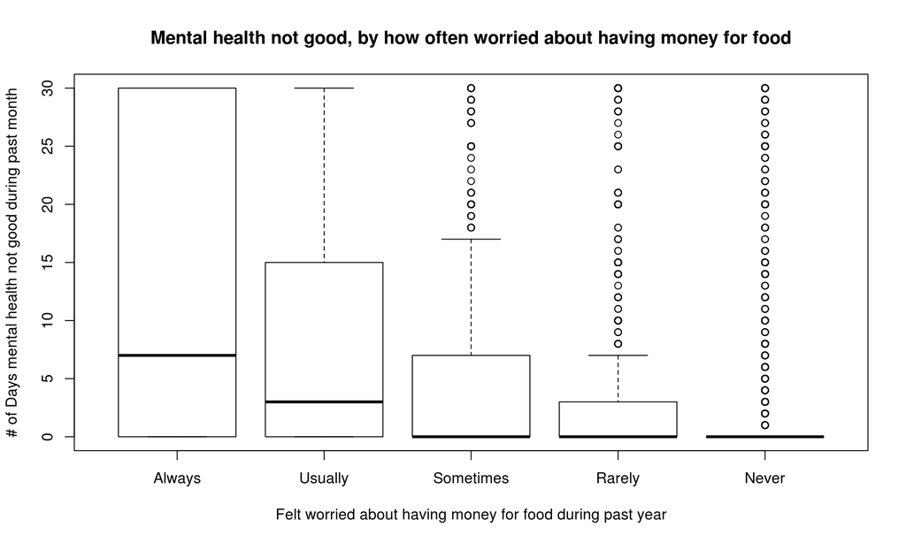

```r
boxplot(menthlth~scntmeal, main="Mental health not good, by how often worried about having money for food", xlab="Felt worried about having money for food during past year", ylab='# of Days mental health not good during past month')
```

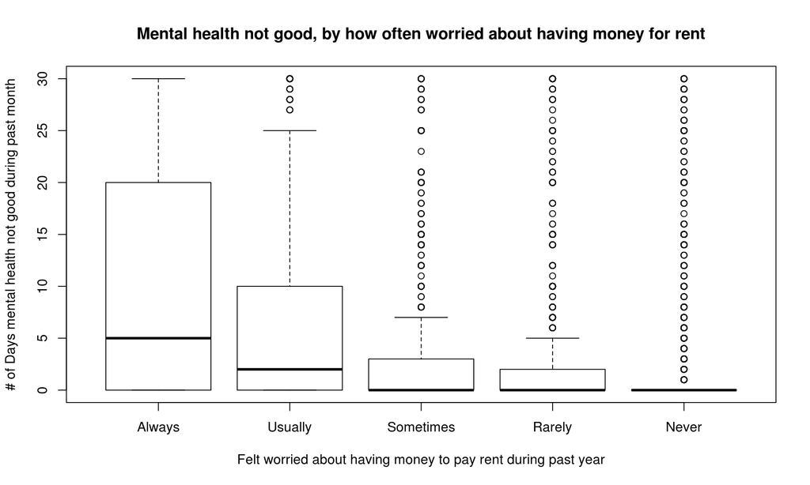

```r
boxplot(menthlth~scntmony, main="Mental health not good, by how often worried about having money for rent", xlab="Felt worried about having money to pay rent during past year", ylab='# of Days mental health not good during past month')
```

**Research quesion 2: Exploring association between a person’s physical activity and their mental health**

For this question we can explore respondents’ mental health status, specifically how many days in the past month they felt they were not in good mental health, for each category of people classified by their physical activity level (1st boxplot), and by their physical activity index (2nd boxplot).

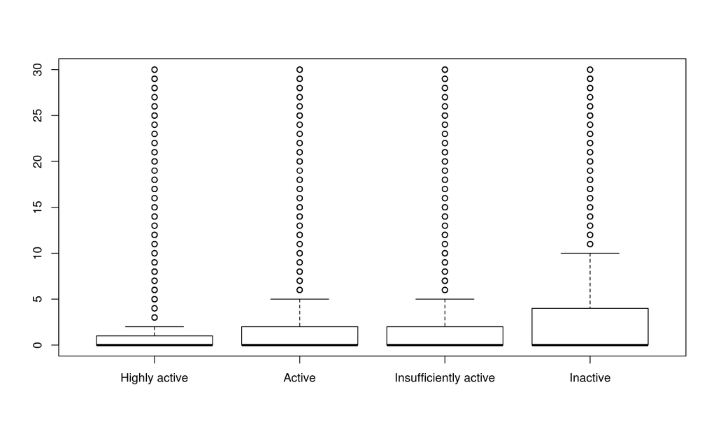

```r
boxplot(menthlth~X_pacat1)
```

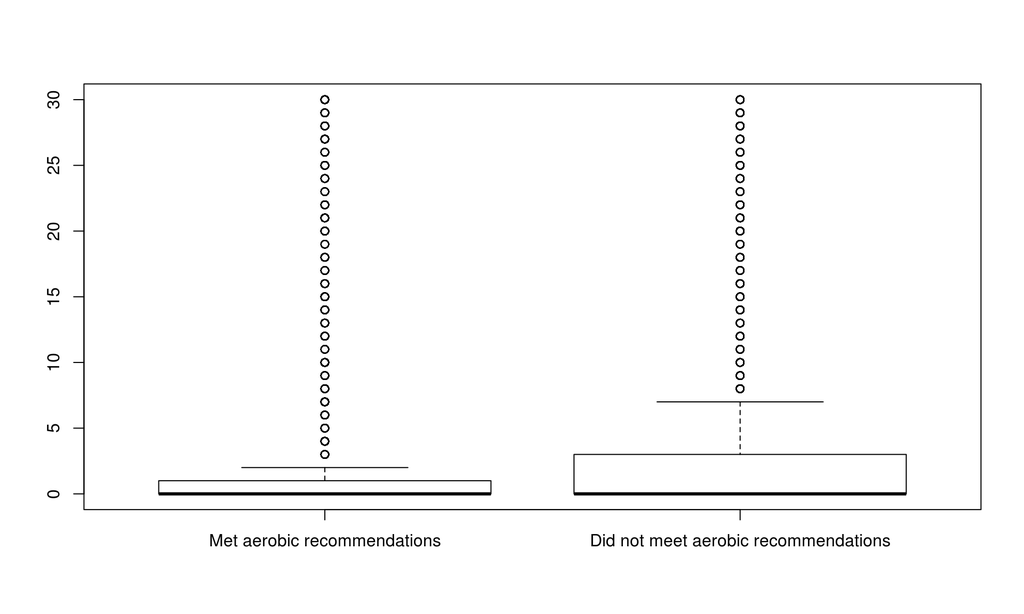

```r
boxplot(menthlth~X_paindx1)
```

Now we will look for associations between whether they have ever been diagnosed with a depressive disorder, and their physical activity. For this we will take a look at the proportion of people diagnosed with the said condition, across each category of people classified by their physical activity.

```r
prop.table(table(addepev2, X_pacat1), 2)
```

```
##         X_pacat1
## addepev2 Highly active    Active Insufficiently active  Inactive
##      Yes     0.1585825 0.1729188             0.2119401 0.2513104
##      No      0.8414175 0.8270812             0.7880599 0.7486896
```

```r
prop.table(table(addepev2, X_paindx1), 2)
```

```
##         X_paindx1
## addepev2 Met aerobic recommendations Did not meet aerobic recommendations
##      Yes                   0.1636289                            0.2366211
##      No                    0.8363711                            0.7633789
```

Exploring association between how often they felt depressed (1st table) or worthless (2nd table) and their physical activity. Showing proportion of people with each response to feeling worthless or depressed, across categories of people classified by their physical activity levels.

```r
table(misdeprd, X_pacat1)
```

```
##           X_pacat1
## misdeprd   Highly active Active Insufficiently active Inactive
##   All                 38     15                    30      156
##   Most               115     61                    65      250
##   Some               338    177                   295      632
##   A little           613    388                   519      802
##   None              9942   5447                  5570     7438
```

```r
prop.table(table(misdeprd, X_pacat1), 2)
```

```
##           X_pacat1
## misdeprd   Highly active      Active Insufficiently active    Inactive
##   All        0.003440159 0.002463863           0.004630344 0.016813969
##   Most       0.010411009 0.010019711           0.010032412 0.026945462
##   Some       0.030599312 0.029073587           0.045531718 0.068118129
##   A little   0.055495202 0.063731932           0.080104954 0.086441043
##   None       0.900054318 0.894710907           0.859700571 0.801681397
```

```r
prop.table(table(misdeprd, X_paindx1), 2)
```

```
##           X_paindx1
## misdeprd   Met aerobic recommendations
##   All                       0.00330736
##   Most                      0.01037054
##   Some                      0.02971019
##   A little                  0.05807500
##   None                      0.89853691
##           X_paindx1
## misdeprd   Did not meet aerobic recommendations
##   All                                0.01180428
##   Most                               0.01999112
##   Some                               0.05883100
##   A little                           0.08383576
##   None                               0.82553786
```

```r
prop.table(table(miswtles, X_pacat1), 2)
```

```
##           X_pacat1
## miswtles   Highly active      Active Insufficiently active    Inactive
##   All        0.005350989 0.005589347           0.007260930 0.024166577
##   Most       0.007890441 0.007233273           0.011277615 0.026108534
##   Some       0.029475785 0.027124774           0.042329677 0.062682058
##   A little   0.048703065 0.055235903           0.065039394 0.075736325
##   None       0.908579721 0.904816702           0.874092384 0.811306506
```

```r
prop.table(table(miswtles, X_paindx1), 2)
```

```
##           X_paindx1
## miswtles   Met aerobic recommendations
##   All                      0.005502218
##   Most                     0.007635731
##   Some                     0.028858571
##   A little                 0.050699006
##   None                     0.907304475
##           X_paindx1
## miswtles   Did not meet aerobic recommendations
##   All                               0.017215093
##   Most                              0.020010164
##   Some                              0.054313302
##   A little                          0.071337822
##   None                              0.837123618
```

**Research quesion 3: Exploring assossiation between lack of sleep, and mental health**

For this we have created another variable, classifying people into two categories: Those who got slept 7 hours or more (which is the mean and median sleep duration according to the survey), and those who slept less than 7 hours a day. After that we will explore the possibility of correlation between the respondents being diagnosed with a depressive disorder, and if they get adequate sleep. Displaying proportion of people who were diagnosed, classified by if they get a minimum of 7 hours of sleep or not.

```r
detach(brfss2013)
brfss2013$adq_sleep <- ifelse(brfss2013$sleptim1<7, "no", "yes")
attach(brfss2013)
table(addepev2, adq_sleep)
```

```
##         adq_sleep
## addepev2     no    yes
##      Yes  39380  54485
##      No  118446 269998
```

```r
prop.table(table(addepev2, adq_sleep), 2)
```

```
##         adq_sleep
## addepev2        no       yes
##      Yes 0.2495153 0.1679133
##      No  0.7504847 0.8320867
```

Exploring association between number of days they felt their mental health was not good, and if they got adequate sleep or not

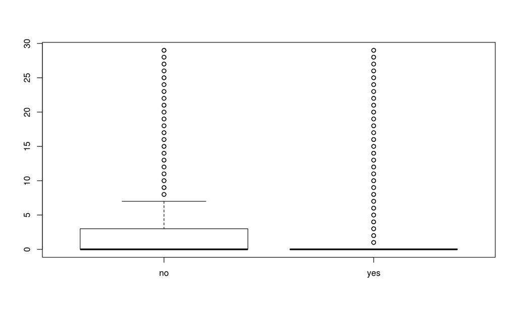

```r
with(subset(brfss2013, menthlth<30), boxplot(menthlth~adq_sleep))
```

Proportion of people who got adequate sleep or not, in each response category of how often they felt worthless or depressed.

```r
prop.table(table(misdeprd, adq_sleep), 1)
```

```
##           adq_sleep
## misdeprd          no       yes
##   All      0.6869919 0.3130081
##   Most     0.5838150 0.4161850
##   Some     0.4964076 0.5035924
##   A little 0.4015304 0.5984696
##   None     0.2813704 0.7186296
```

```r
prop.table(table(miswtles, adq_sleep), 1)
```

```
##           adq_sleep
## miswtles          no       yes
##   All      0.6297297 0.3702703
##   Most     0.5485961 0.4514039
##   Some     0.4841883 0.5158117
##   A little 0.4054180 0.5945820
##   None     0.2840705 0.7159295
```